# R for Data Science

홍우헌

quasar103@naver.com

2018-08-03

> Part 1  
> Explore (2)

# 1 Chapter 5 : EDA

1. 데이터에 대한 문제 생성
2. 시각화, 변환, 모델링으로 답을 찾아라
3. 문제를 개선하거나 새로운 문제를 생성

EDA의 목적은 데이터의 이해.

두가지 유형의 질문이 데이터 내에 발견에 도움을 준다.

1. 변수내에 일어나는 변동의 유형은?
2. 변수간의 생기는 공분산의 유형은?
- 변수(variable)는 양, 질, 측정이 가능한 속성이다.
- 값(value)은 측정할 때 변수의 상태이다. 변수의 값은 측정마다 다르다.
- 관측(observation)은 비슷한 조건에서의 측정의 집합이다.
- Tabular data는 변수와 관측에 연관되는 값의 집합이다. Tabular data는 만약 각 값이 자신의 cell에 있고, 각 변수가 자신의 열에, 그리고 각 관측이 자신의 행에 있다면 tidy.

## 1.1 Variation

변수의 분포를 시각화 해보자.

### 1.1.1 Visualizing Distributions

범주형 변수

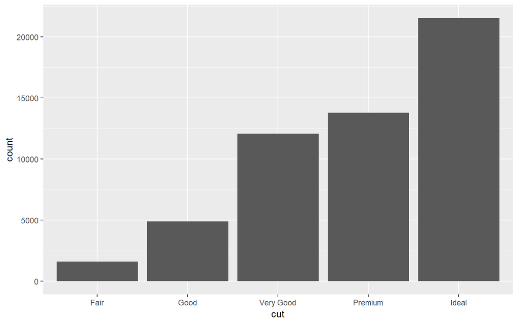

```r
ggplot(diamonds) +
  geom_bar(aes(cut))
```

```r
diamonds %>%
  count(cut)
```

```
## # A tibble: 5 x 2
##   cut           n
##   <ord>     <int>
## 1 Fair       1610
## 2 Good       4906
## 3 Very Good 12082
## 4 Premium   13791
## 5 Ideal     21551
```

연속형 변수

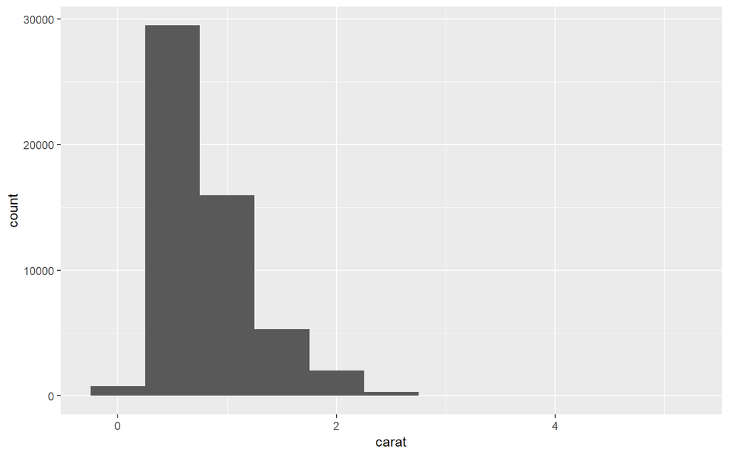

```r
ggplot(diamonds) +
  geom_histogram(aes(carat), binwidth = 0.5)
```

```r
diamonds %>%
  count(cut_width(carat, 0.5))
```

```
## # A tibble: 11 x 2
##    `cut_width(carat, 0.5)`     n
##    <fct>                   <int>
##  1 [-0.25,0.25]              785
##  2 (0.25,0.75]             29498
##  3 (0.75,1.25]             15977
##  4 (1.25,1.75]              5313
##  5 (1.75,2.25]              2002
##  6 (2.25,2.75]               322
##  7 (2.75,3.25]                32
##  8 (3.25,3.75]                 5
##  9 (3.75,4.25]                 4
## 10 (4.25,4.75]                 1
## 11 (4.75,5.25]                 1
```

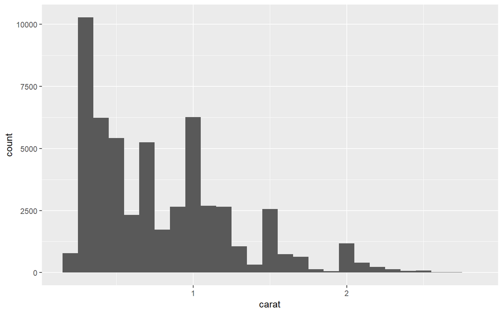

```r
smaller <- diamonds %>%
  filter(carat < 3)
  ggplot(smaller, aes(carat)) +
    geom_histogram(binwidth = 0.1)
```

다수의 히스토그램을 겹쳐 그리고자 한다면 `geom_histogram()` 대신 `geom_freqpoly()`를 사용하라. 막대보다 선이 겹쳤을 때 보기 좋다.

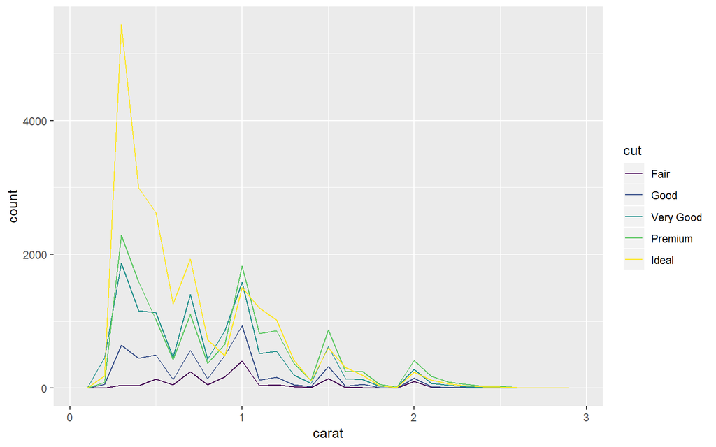

```r
ggplot(smaller, aes(carat, color = cut)) +
  geom_freqpoly(binwidth = 0.1)
```

### 1.1.2 Typical Values

• Which values are the most common? Why? • Which values are rare? Why? Does that match your expectations? • Can you see any unusual patterns? What might explain them?

As an example, the following histogram suggests several interesting questions:

• Why are there more diamonds at whole carats and common fractions of carats? • Why are there more diamonds slightly to the right of each peak than there are slightly to the left of each peak? • Why are there no diamonds bigger than 3 carats?

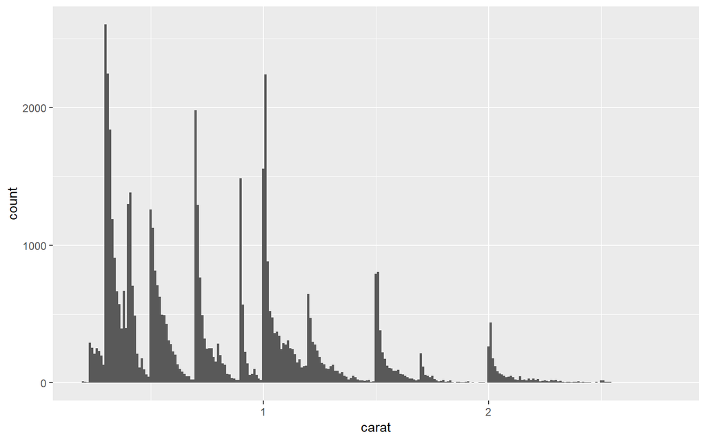

```r
ggplot(smaller, aes(carat)) +
  geom_histogram(binwidth = 0.01)
```

일반적으로 비슷한 값의 클러스터가 서브그룹이 데이터에 존재함을 암시한다. 서브그룹을 이해하기 위해

- 각 클러스터 내에 관측치가 서로 비슷한가?
- 개별 클러스터에 관측치가 서로 다른가?
- 클러스터를 어떻게 설명할 것인가?
- 클러스터의 형태가 잘못됐나?

다음 히스토그램은 짧은 분화와 긴 분화가 있다.

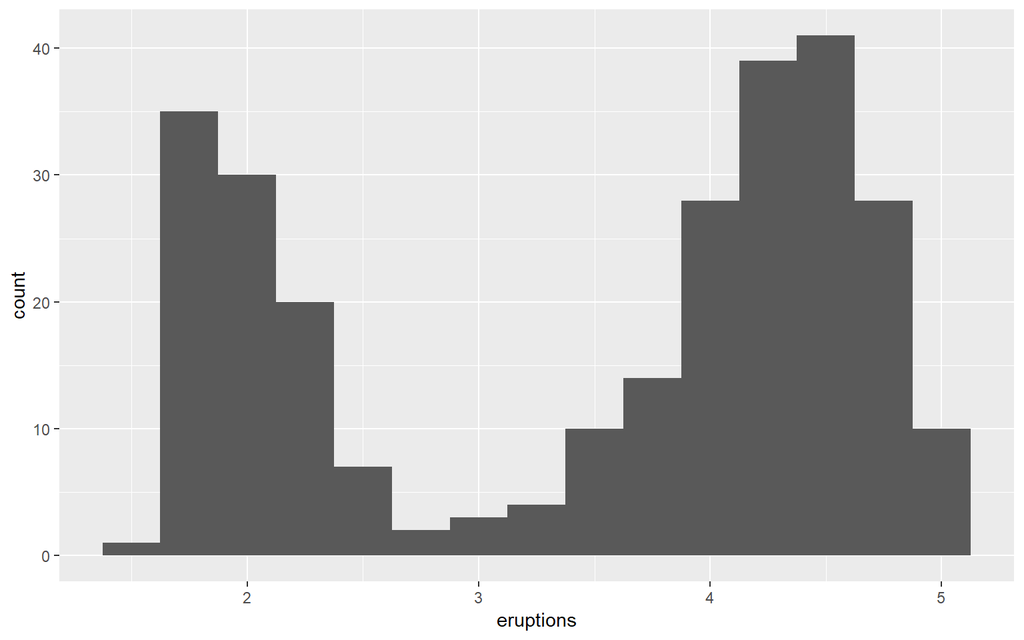

```r
ggplot(faithful, aes(eruptions)) +
  geom_histogram(binwidth = 0.25)
```

### 1.1.3 Unusual Values

이상치를 주의하자. 때떄로 이상치는 입력 오류일 수 있다. 다른 경우에는 중요한 새로운 발견일 수 있다. 데이터가 크다면 히스토그램에서 이상치를 보기 어렵다.

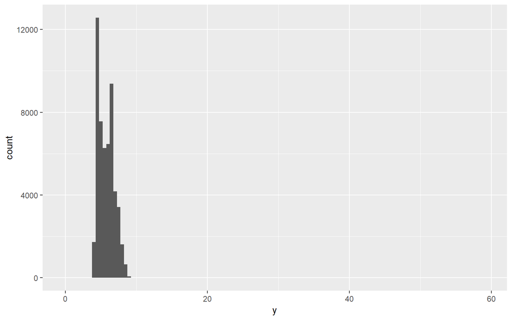

```r
ggplot(diamonds) +
  geom_histogram(aes(x = y), binwidth = 0.5)
```

x축 뿐만이 아니라 y축을 수정해도 이상치를 찾을 수 있다.

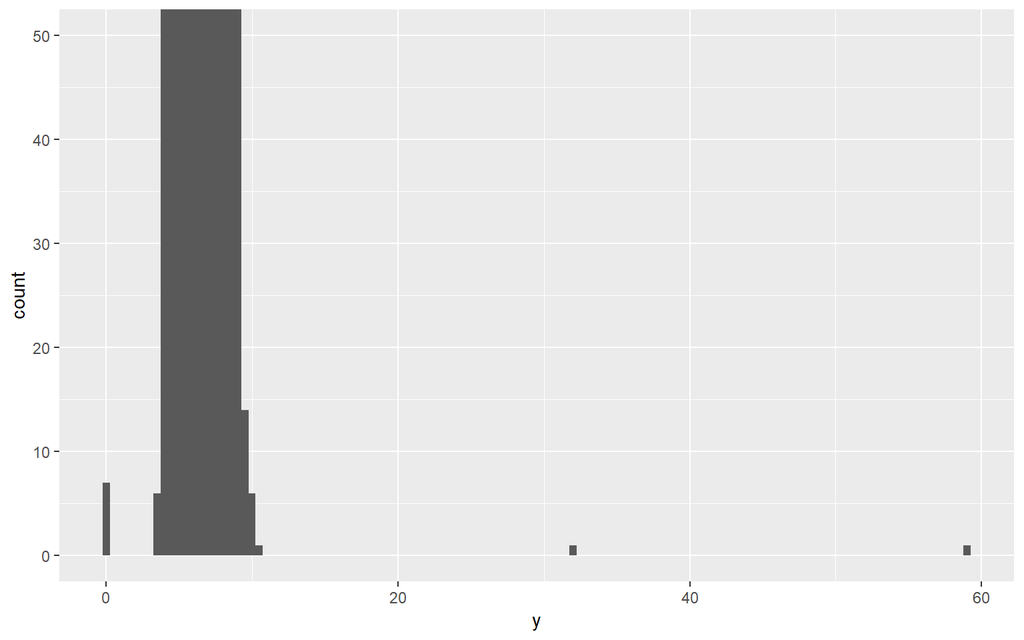

```r
ggplot(diamonds) +
  geom_histogram(aes(x = y), binwidth = 0.5) +
  coord_cartesian(ylim = c(0, 50)) # 특이한 값을 보기위해
```

```r
unusual <- diamonds %>%
  filter(y < 3 | y > 20) %>%
  arrange(y)
```

## 1.2 Exercises

1. Explore the distribution of each of the x, y, and z variables in diamonds. What do you learn? Think about a diamond and how you might decide which dimension is the length, width, and depth.

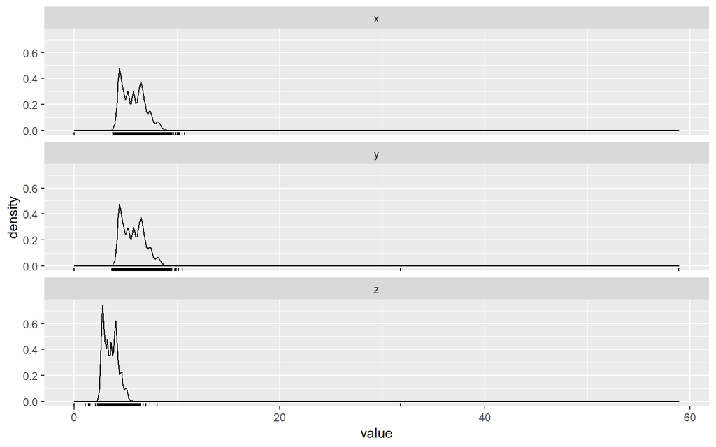

```r
diamonds %>%
  mutate(id = row_number()) %>%
  select(x, y, z, id) %>%
  gather(variable, value, -id) %>%
  ggplot(aes(value)) +
    geom_density() +
    geom_rug() +
    facet_wrap(~variable, ncol = 1)
```

rug를 보면 이상치가 있음을 알 수 있다.

2. Explore the distribution of price. Do you discover anything unusual or surprising? (Hint: carefully think about the bin width and make sure you try a wide range of values.)

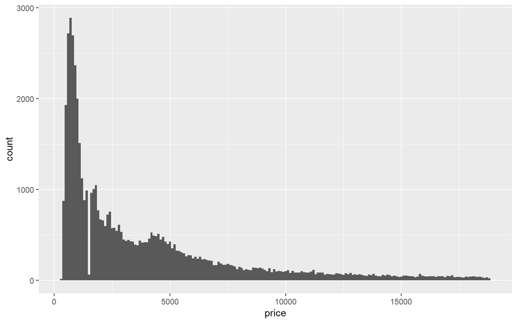

```r
ggplot(diamonds, aes(price)) +
  geom_histogram(binwidth = 100)
```

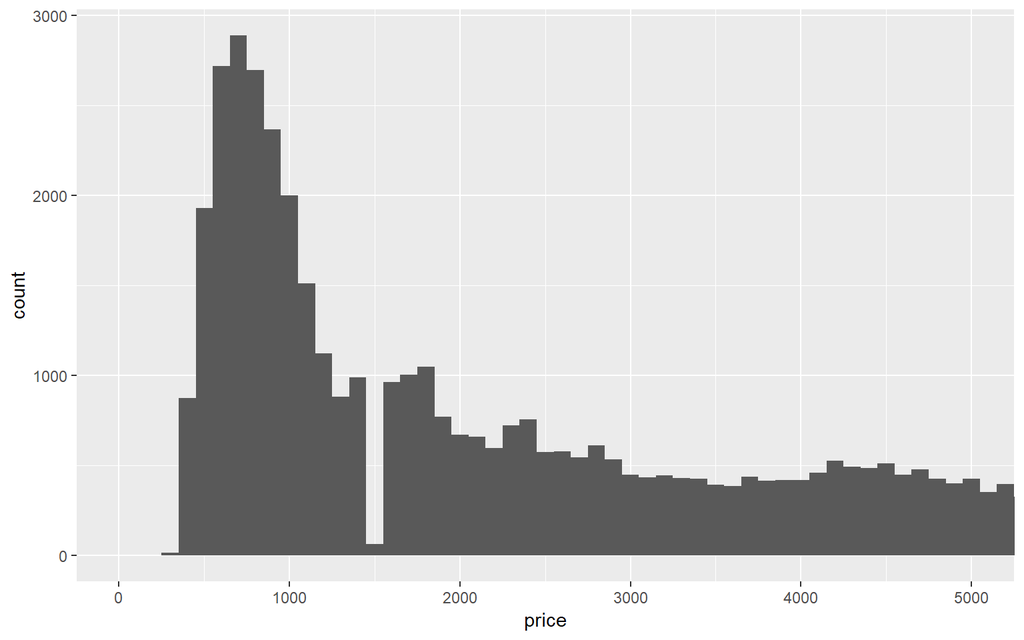

```r
ggplot(diamonds, aes(price)) +
  geom_histogram(binwidth = 100) +
  coord_cartesian(xlim = c(0, 5000))
```

1500달러의 다이아가 없다.

다이아의 가격이 들쑥날쑥하니까 패턴을 알아보겠다.

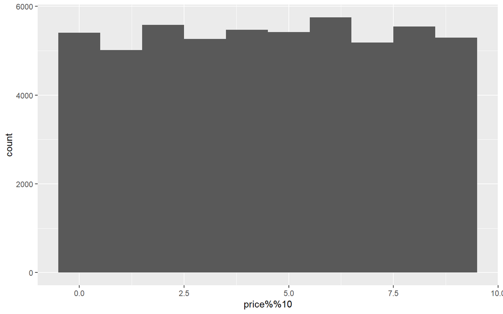

```r
ggplot(diamonds, aes(price %% 10)) +
  geom_histogram(binwidth = 1)
```

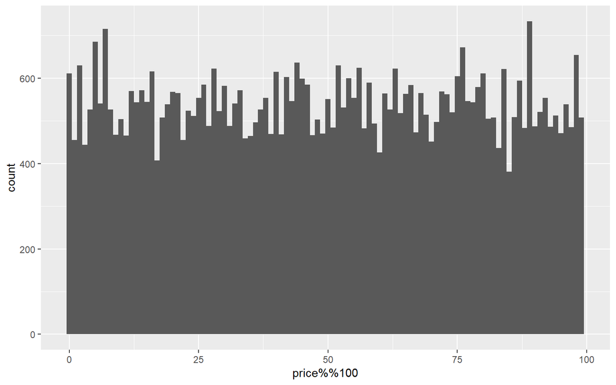

```r
ggplot(diamonds, aes(price %% 100)) +
  geom_histogram(binwidth = 1)
```

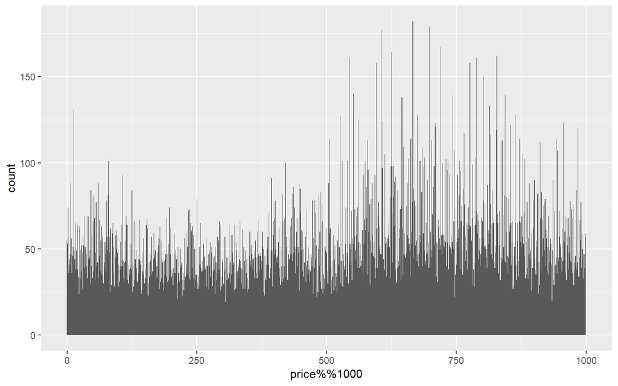

```r
ggplot(diamonds, aes(price %% 1000)) +
  geom_histogram(binwidth = 1)
```

3. How many diamonds are 0.99 carat? How many are 1 carat? What do you think is the cause of the difference?

```r
diamonds %>%
  filter(carat >= 0.99, carat<= 1) %>%
  count(carat)
```

```
## # A tibble: 2 x 2
##   carat     n
##   <dbl> <int>
## 1  0.99    23
## 2  1     1558
```

비싸게 팔려고 0.99를 1로 올림한 것 같다. 예제의 히스토그램과 다음 코드를 참고하면 그럴 수도 있을 것 같다.

```r
diamonds %>%
  filter(carat >= 0.9, carat <= 1.1) %>%
  count(carat) %>%
  print(n = 30)
```

```
## # A tibble: 21 x 2
##    carat     n
##    <dbl> <int>
##  1  0.9   1485
##  2  0.91   570
##  3  0.92   226
##  4  0.93   142
##  5  0.94    59
##  6  0.95    65
##  7  0.96   103
##  8  0.97    59
##  9  0.98    31
## 10  0.99    23
## 11  1     1558
## 12  1.01  2242
## 13  1.02   883
## 14  1.03   523
## 15  1.04   475
## 16  1.05   361
## 17  1.06   373
## 18  1.07   342
## 19  1.08   246
## 20  1.09   287
## 21  1.1    278
```

4. Compare and contrast coord_cartesian() versus xlim() or ylim() when zooming in on a histogram. What happens if you leave binwidth unset? What happens if you try and zoom so only half a bar shows?

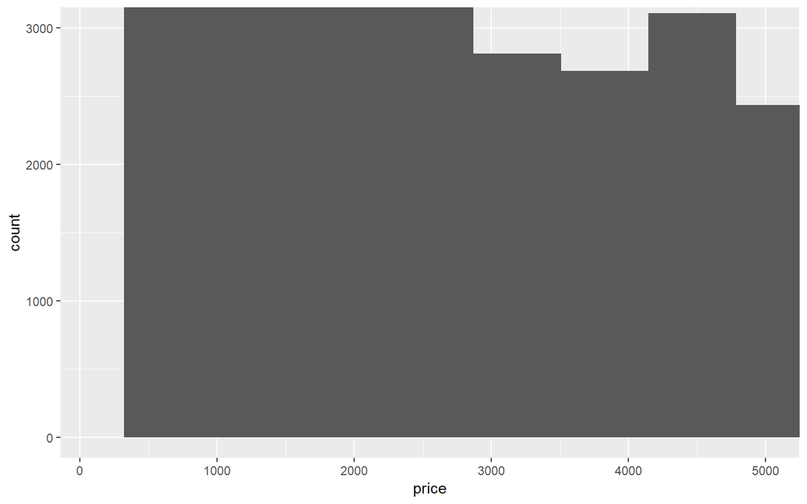

```r
ggplot(diamonds) +
  geom_histogram(mapping = aes(x = price)) +
  coord_cartesian(xlim = c(100, 5000), ylim = c(0, 3000))
```

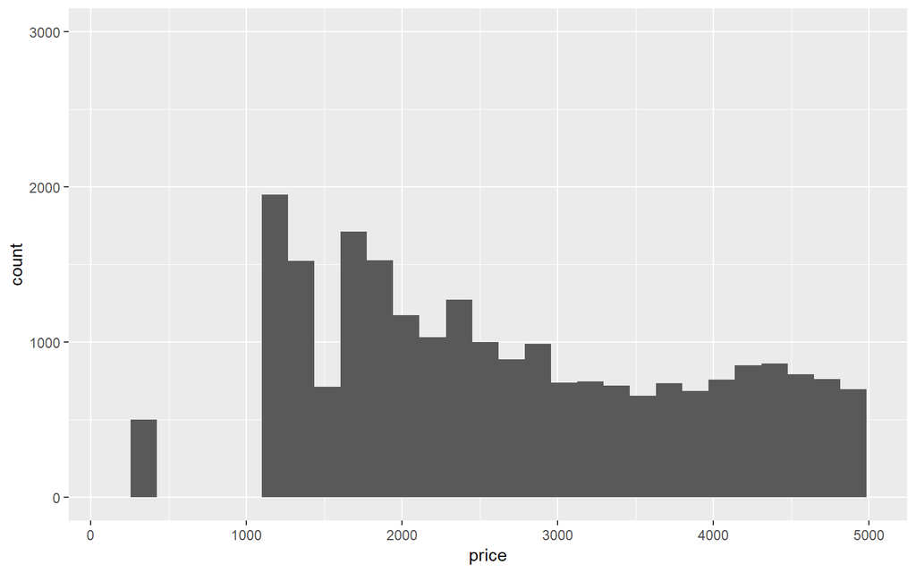

```r
# coord_cartesian은 사용하여도 히스토그램 계산이 바뀌지 않는다.

ggplot(diamonds) +
  geom_histogram(mapping = aes(x = price)) +
  xlim(100, 5000) +
  ylim(0, 3000)
```

### 1.2.1 Missing Values

데이터셋에서 특이값에 마주쳐서 분석의 나머지로 단순히 나아간다면 두가지 선택 사항이 있다.

- 행을 삭제하라.

하나의 측정이 이상하다고 해서 모든 측정이 그런 것을 의미하는 것은 아니므로 추천하지는 않는다.

- 이상한 값을 NA로 대체하라.

```r
diamonds2 <- diamonds %>% mutate(y = ifelse(y < 3 | y > 20, NA, y))
```

ggplot2는 NA를 플랏에 포함하지 않고 제거했다는 경고만 표시한다.

```
## Warning: Removed 9 rows containing missing values (geom_point).
```

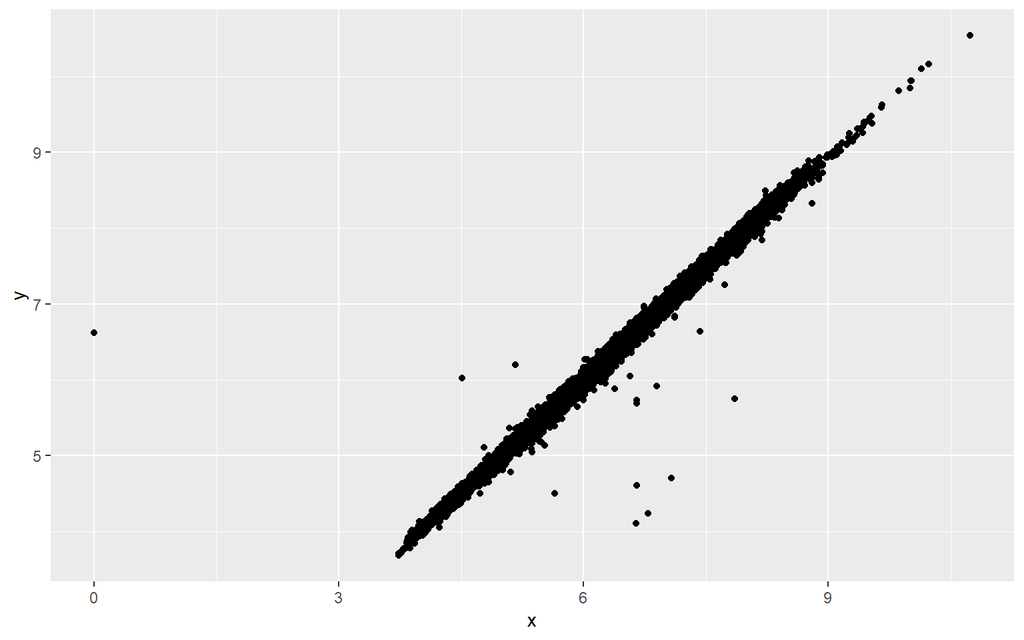

```r
ggplot(diamonds2, aes(x, y)) +
  geom_point()
```

```r
ggplot(diamonds2, aes(x, y)) +
  geom_point(na.rm = TRUE) # 경고 표시 X
```

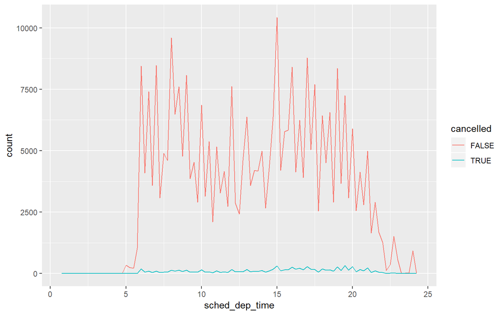

```r
flights %>%
  mutate(
    cancelled = is.na(dep_time),
    sched_hour = sched_dep_time %/% 100,
    sched_min = sched_dep_time %% 100,
    sched_dep_time = sched_hour + sched_min / 60
  ) %>%
  ggplot(aes(sched_dep_time)) +
    geom_freqpoly(
      aes(color = cancelled),
      binwidth = 1/4
    )
```

이 플랏은 취소되지 않은 항공편이 취소된 항공편보다 너무 많으므로 좋지 않다.

> if_else

Compared to the base ifelse(), this function is more strict. It checks that true and false are the same type. This strictness makes the output type more predictable, and makes it somewhat faster.

```r
x <- c(-5:5, NA)
if_else(x < 0, NA_integer_, x)
```

```
##  [1] NA NA NA NA NA  0  1  2  3  4  5 NA
```

```r
# if_else(x < 0, NA, x) : error 대신 ifelse사용해야함

if_else(x < 0, "negative", "positive", "missing")
```

```
##  [1] "negative" "negative" "negative" "negative" "negative" "positive"
##  [7] "positive" "positive" "positive" "positive" "positive" "missing"
```

```r
# Unlike ifelse, if_else preserves types
x <- factor(sample(letters[1:5], 10, replace = TRUE))
ifelse(x %in% c("a", "b", "c"), x, factor(NA))
```

```
##  [1]  2  3 NA  3  3  1  3 NA NA NA
```

```r
if_else(x %in% c("a", "b", "c"), x, factor(NA))
```

```
##  [1] b    c    <NA> c    c    a    c    <NA> <NA> <NA>
## Levels: a b c d e
```

## 1.3 Exericses

What happens to missing values in a histogram? What happens to missing values in a bar chart? Why is there a difference?

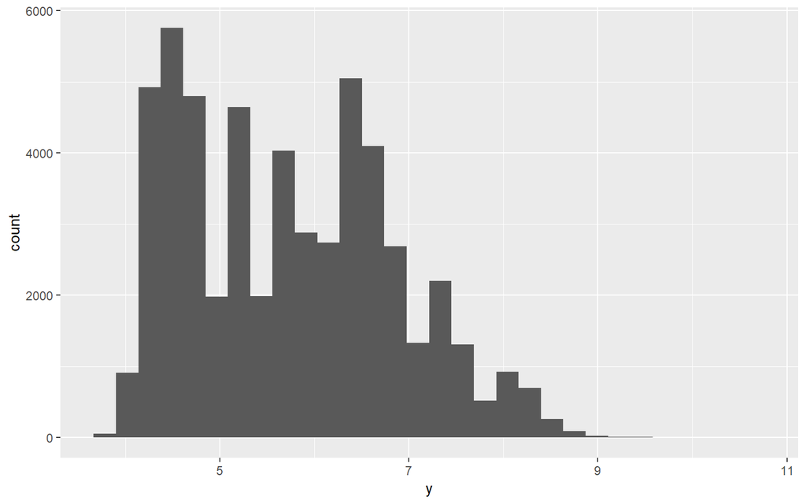

```r
diamonds2 <- diamonds %>%
  mutate(y = ifelse(y < 3 | y > 20, NA, y))

ggplot(diamonds2, aes(x = y)) +
  geom_histogram() # NA 제거
```

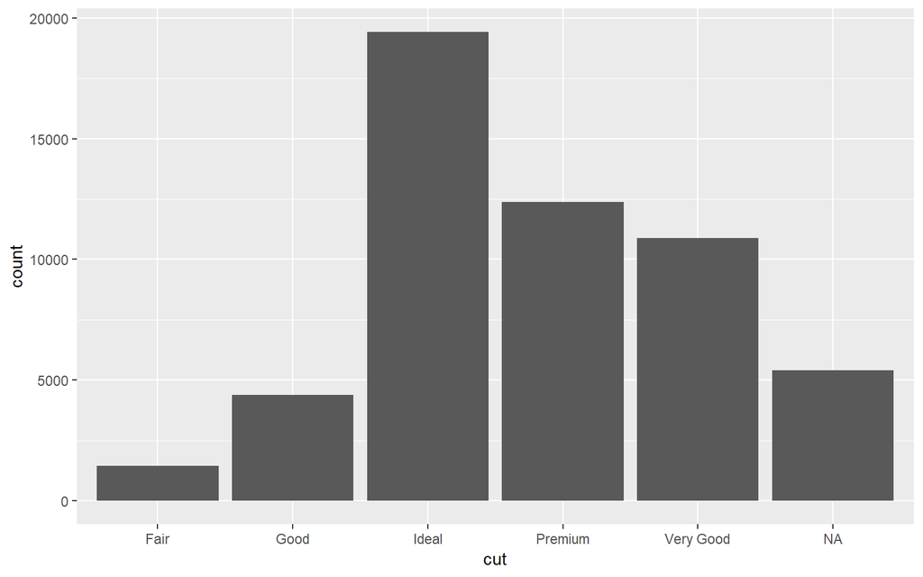

```r
diamonds %>%
  mutate(cut = if_else(runif(n()) < 0.1, NA_character_, as.character(cut))) %>%
  ggplot() +
  geom_bar(mapping = aes(x = cut)) # NA 범주로 인식하고 나타냄
```

## 1.4 Covariation

### 1.4.1 A Categorical and Continuous Variable

`geom_freqpoly()`의 디폴트는 높이가 count이므로 유용하지 않다.

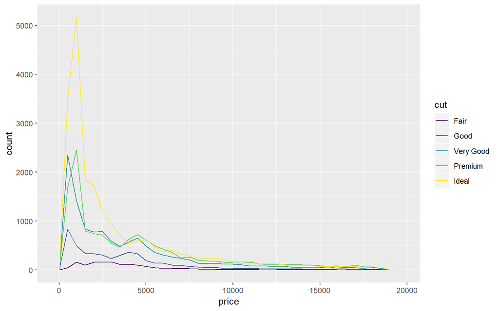

```r
ggplot(data = diamonds, mapping = aes(x = price)) +
  geom_freqpoly(mapping = aes(color = cut), binwidth = 500)
```

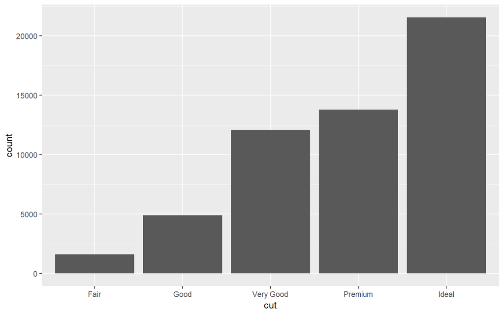

```r
ggplot(diamonds) + # 개수가 너무 다르다.
  geom_bar(aes(cut))
```

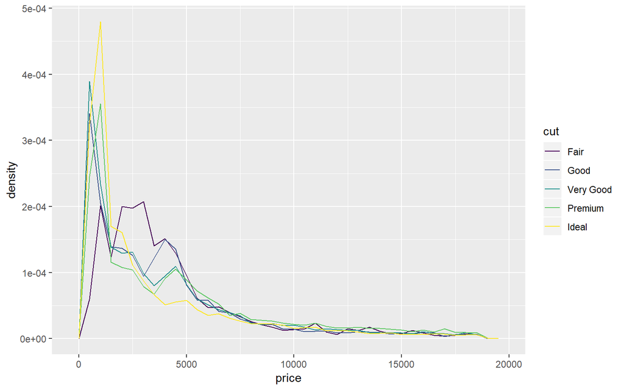

```r
ggplot(diamonds, aes(price, ..density..)) +
  geom_freqpoly(aes(color = cut), binwidth = 500)
```

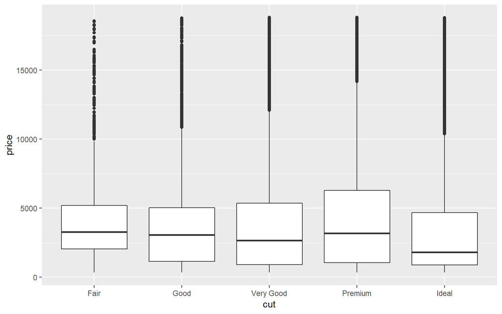

```r
ggplot(diamonds, aes(cut, price)) +
  geom_boxplot()
```

```r
ggplot(mpg) +
  geom_boxplot(aes(reorder(class, hwy, FUN = median), hwy)) +# reorder 기억해두자.
  coord_flip() # 변수 이름이 길 때
```

## 1.5 Exercises

1. Use what you’ve learned to improve the visualization of the departure times of cancelled versus noncancelled flights.

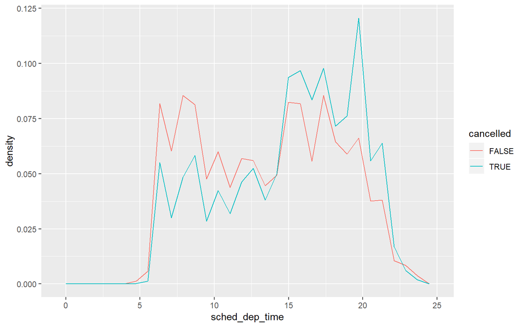

```r
flights %>%
  mutate(cancelled = is.na(dep_time),
         sched_hour = sched_dep_time %/% 100,
         sched_min = sched_dep_time %% 100,
         sched_dep_time = sched_hour + sched_min / 60) %>%
  ggplot(aes(sched_dep_time, ..density..)) +
    geom_freqpoly(aes(color = cancelled))
```

오후에 취소가 많이 된 것 같다.

2. What variable in the diamonds dataset is most important for predicting the price of a diamond? How is that variable correlated with cut? Why does the combination of those two relationships lead to lower quality diamonds being more expensive?

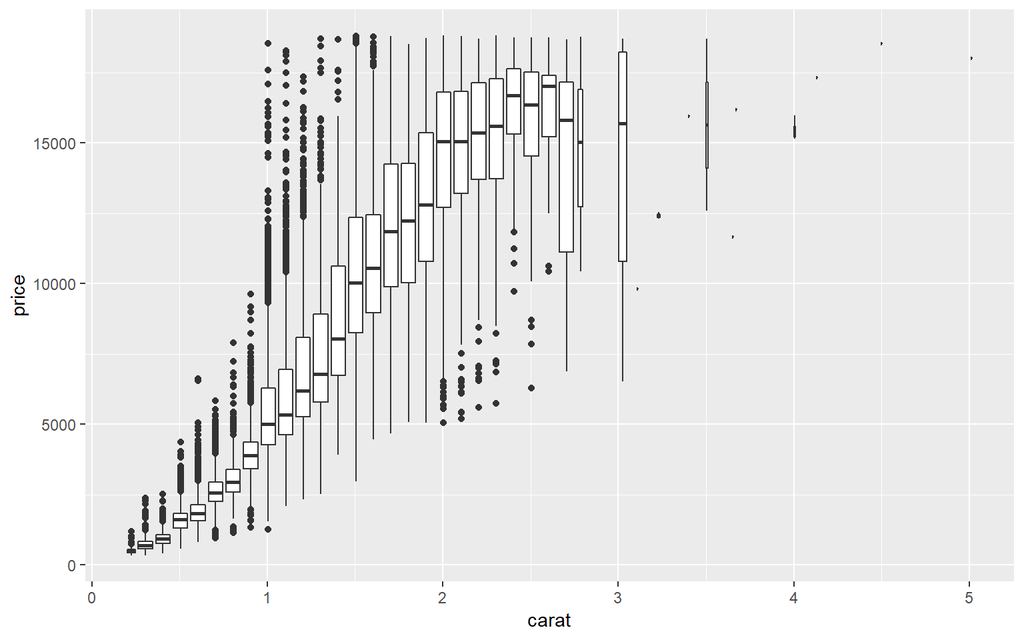

```r
# x변수 carat을 변환시키는 것이 아닌 group을 지정해야 축이 원하는대로 출력됨.
ggplot(diamonds, aes(carat, price)) +
  geom_boxplot(aes(group = cut_width(carat, 0.1)))
```

다른변수들은 이정도의 상관성을 띄지 않는다.

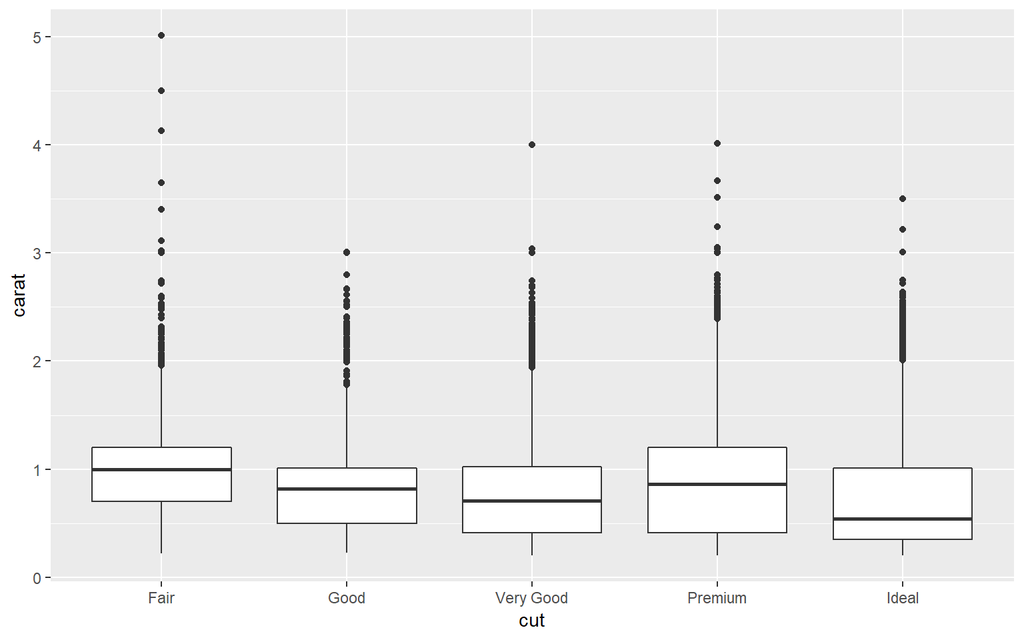

```r
ggplot(diamonds, aes(cut, carat)) +
  geom_boxplot()
```

```r
summary(lm(carat ~ cut - 1, diamonds))
```

```
##
## Call:
## lm(formula = carat ~ cut - 1, data = diamonds)
##
## Residuals:
##     Min      1Q  Median      3Q     Max
## -0.8261 -0.3764 -0.1064  0.2580  3.9639
##
## Coefficients:
##              Estimate Std. Error t value Pr(>|t|)
## cutFair      1.046137   0.011603   90.17   <2e-16 ***
## cutGood      0.849185   0.006647  127.76   <2e-16 ***
## cutVery Good 0.806381   0.004235  190.39   <2e-16 ***
## cutPremium   0.891955   0.003964  225.00   <2e-16 ***
## cutIdeal     0.702837   0.003171  221.63   <2e-16 ***
## ---
## Signif. codes:  0 '***' 0.001 '**' 0.01 '*' 0.05 '.' 0.1 ' ' 1
##
## Residual standard error: 0.4655 on 53935 degrees of freedom
## Multiple R-squared:  0.7484, Adjusted R-squared:  0.7484
## F-statistic: 3.209e+04 on 5 and 53935 DF,  p-value: < 2.2e-16
```

cut이 좋지 않을 수록 carat의 effect가 커진다.

3. Install the ggstance package, and create a horizontal boxplot. How does this compare to using coord_flip()?

```r
# install.packages("ggstance")
ggplot(mpg, aes(reorder(class, hwy, FUN = median), hwy)) +
  geom_boxplot() +
  coord_flip()
```

```r
ggplot(mpg, aes(hwy, reorder(class, hwy, FUN = median))) +
  ggstance::geom_boxploth()
```

뭐가 좋은지 모르겠다.

4. One problem with boxplots is that they were developed in an era of much smaller datasets and tend to display a prohibitively large number of “outlying values.” One approach to remedy this problem is the letter value plot. Install the lvplot package, and try using geom_lv() to display the distribution of price versus cut. What do you learn? How do you interpret the plots?

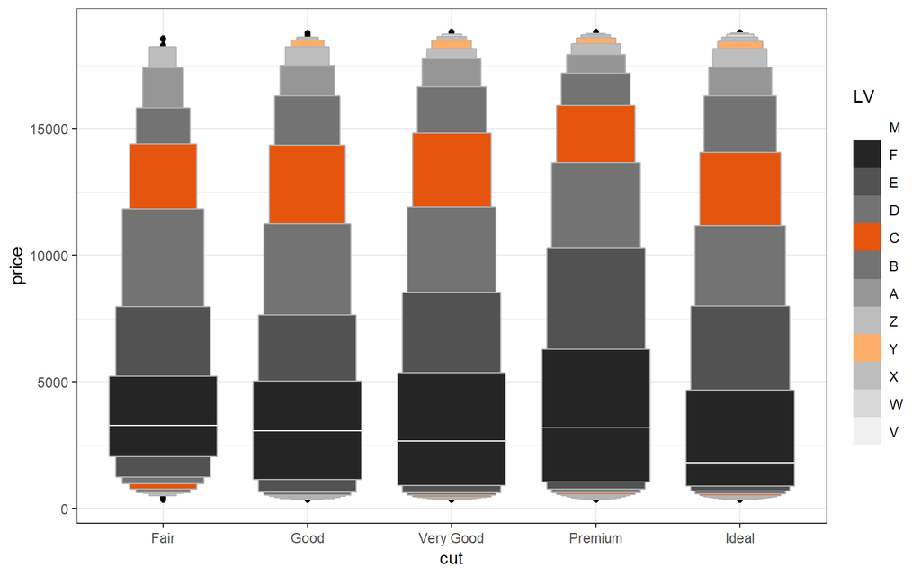

```r
# install.packages("lvplot")

library(lvplot)
ggplot(diamonds, aes(cut, price)) +
  geom_lv(aes(fill = ..LV..)) +
  scale_fill_lv() +
  theme_bw()
```

이상치가 5~8개가 되도록 상자갯수를 정한다.

5. Compare and contrast geom_violin() with a faceted geom_his togram(), or a colored geom_freqpoly(). What are the pros and cons of each method?

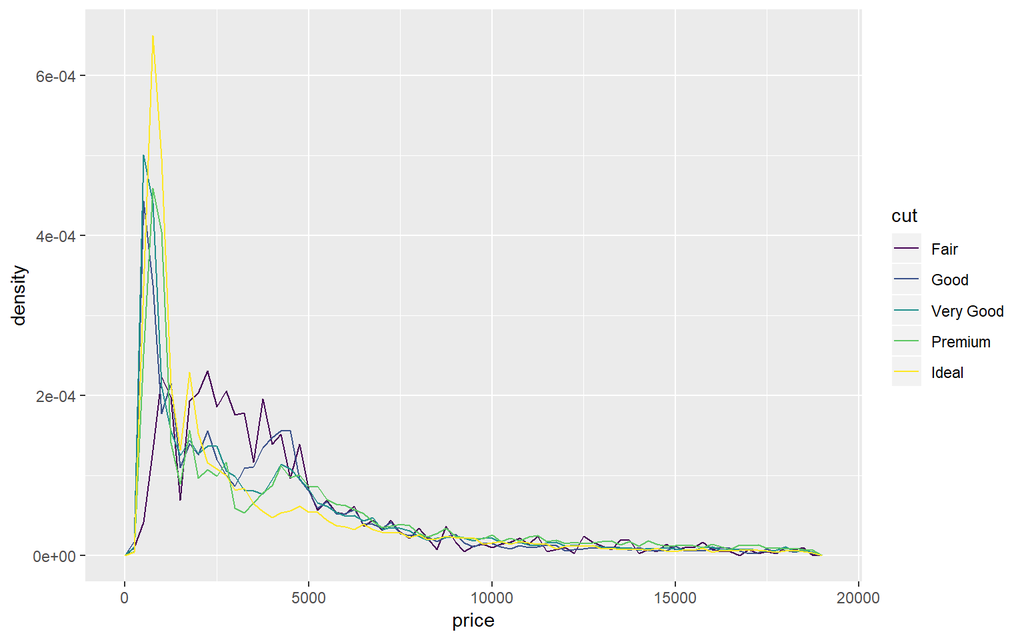

```r
ggplot(diamonds, aes(price, stat(density))) +
  geom_freqpoly(aes(color = cut), binwidth =250)
```

어떤 cut이 가장 밀도가 높은지는 찾기 쉽지만 전반적인 분포가 서로 어떻게 되는지는 overlapping line으로 보기 어렵다

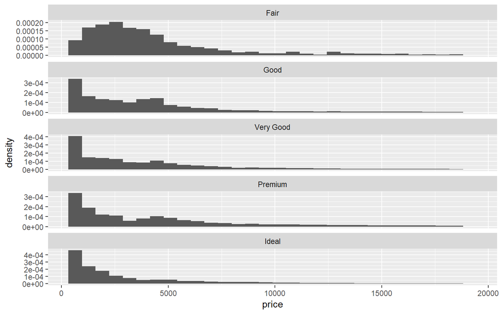

```r
ggplot(diamonds, aes(price, stat(density))) +
  geom_histogram() +
  facet_wrap(~cut, ncol = 1, scales = "free_y")
```

분포의 전박적인 모양은 보기 쉽지만 y값을 비교하기 어렵다.

6. If you have a small dataset, it’s sometimes useful to use geom_jitter() to see the relationship between a continuous and categorical variable. The ggbeeswarm package provides a number of methods similar to geom_jitter(). List them and briefly describe what each one does.

https://github.com/eclarke/ggbeeswarm 참고

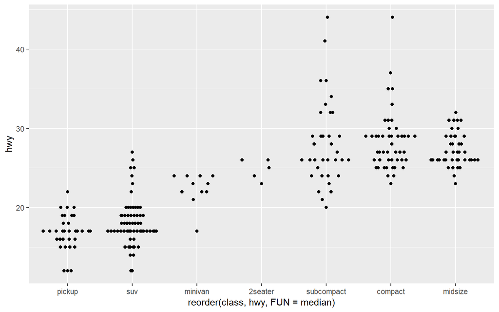

```r
ggplot(data = mpg) +
  ggbeeswarm::geom_quasirandom(mapping = aes(x = reorder(class, hwy, FUN = median),y = hwy))
```